```python
import pandas as pd
import numpy as np
import seaborn as sns
```

# 문제 1 - 20점

### 문제 [1-1] - 3점

### 2023년 1월 29일, 자신의 이름, MBTI, 핸드폰 번호 뒷자리를 리스트로 저장하고 그것을 Series의 형태로 변환하여 출력하세요.

<출력예시>

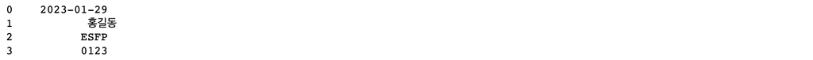

### 문제 [1-2] - 3점

### 딕셔너리를 사용하여 다음의 DataFrame 모양을 만들어 출력하세요.(DataFrame은 df로 저장해주세요)

<출력예시>

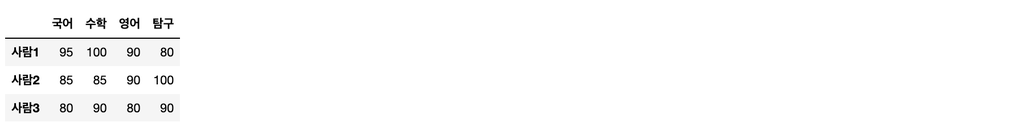

### 문제 [1-3] - 3점

### 위에서 만들어진 df에서 '탐구'열(column)을 삭제하고 출력하세요.

<출력예시>

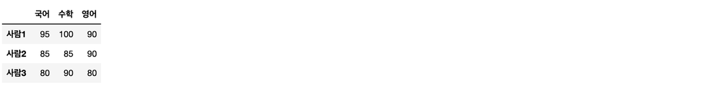

### 문제 [1-4] - 4점

### df에 국어, 수학, 영어 3과목의 평균 점수를 나타내는 '평균' 열(column)을 추가하여 출력하세요.(소수점 세번째 자리에서 반올림하여 소수점 둘째자리까지만 나타내세요)

<출력예시>

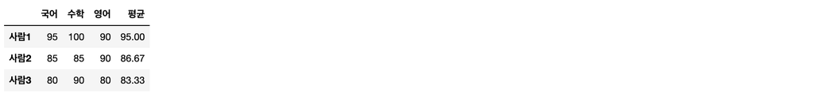

### 문제 [1-5] - 7점

### '평균'열에 나온 점수를 기준으로 등급으로 변환한 '등급'열을 추가하여 출력하세요(95점 이상 A+, 90점 이상 A, 85점 이상 B+, 80점 이상 B 입니다.)

<출력예시>

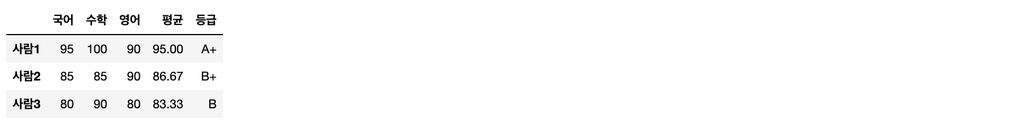

# 문제 2 - 25점

### 문제 [2-1] - 3점

### spotify.csv 파일을 불러오고 data 변수에 저장하여 맨 위에 3개 행을 출력하세요.

<출력예시>

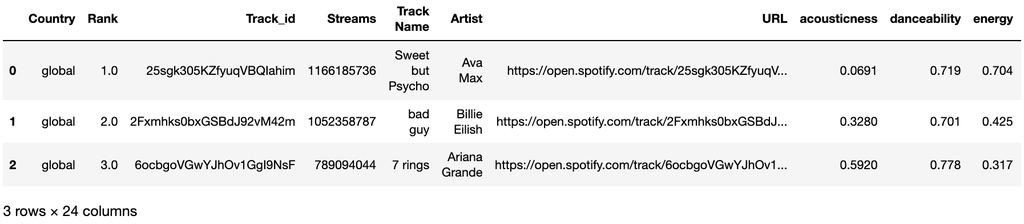

### 문제 [2-2] - 3점

### data의 열(column) 중에서 'Artist'열에서 고유값의 종류와 갯수를 확인할 수 있는 함수를 사용하여, 다음과 같이 출력하세요.

<출력예시>

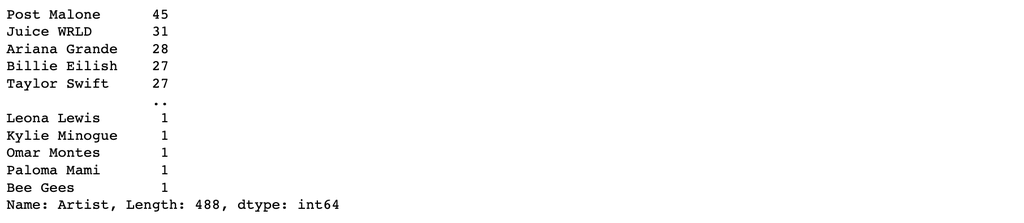

### 문제 [2-3] - 5점

### 'Artist'열에서 아티스트가 BTS인 행들을 찾아 출력하세요.

<출력예시>

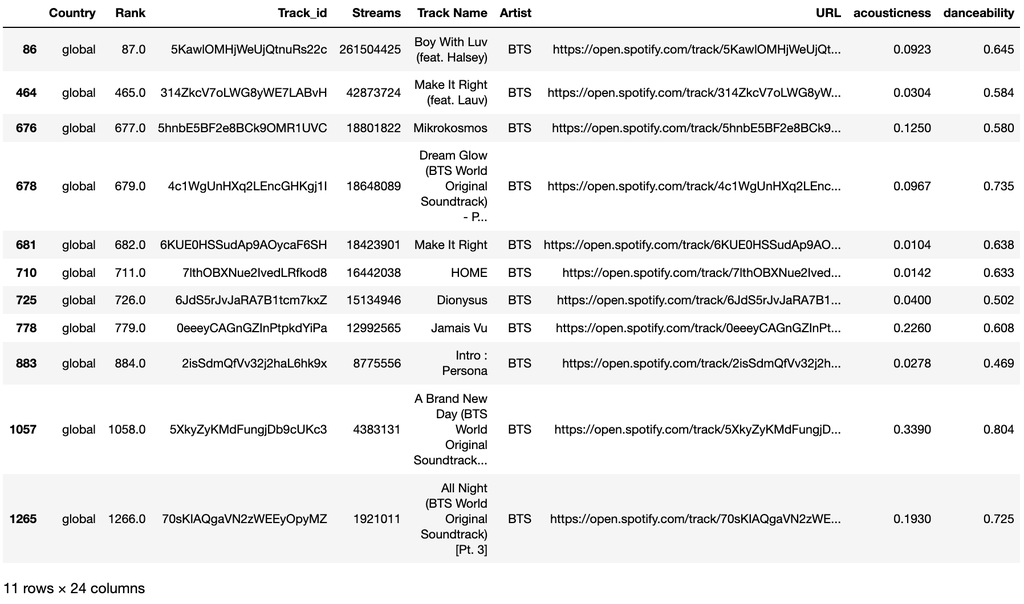

### 문제 [2-4] - 7점

### 'tempo' 열에 대한 히스토그램을 그려주세요.

#### (구간은 총 10개로 나누고 그림 사이즈는 (10,5)로 설정하여 나타내어 주세요)

<출력예시>

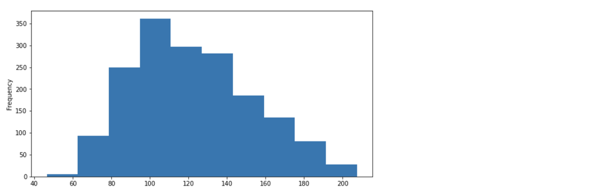

### 문제 [2-5] - 7점

### 'Artist'가 BTS이면서 'Tempo'가 평균 이상인 것들을 다음과 같이 출력하세요.

#### (열(column)은 Rank, Track Name, Artist, tempo만 나오도록 하세요)

<출력예시>

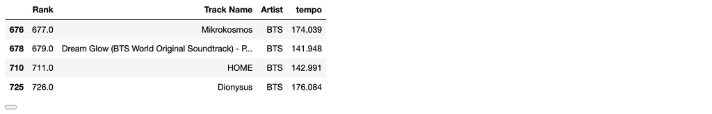

# 문제 3 - 20점

### (아래 코드를 실행시켜 df1 변수에 저장 후, 시작해주세요)

```python
df1 =pd.DataFrame({'Class': ['IoT','Network', 'Economy','Big Data', 'Cloud'],
                       'Year': [2018, 2017, 2018, 2018, 2019],
                       'Price': [100, 125, 132, 312, 250],
                       'limitStudent': [40, 40, 40, 40, 40],
                       'Location': ['Korea','Korea', 'Korea', 'US','Korea']},
                      index=['C01','C02','C03', 'C04', 'C05'])
df1
```

|  | Class | Year | Price | limitStudent | Location |
| --- | --- | --- | --- | --- | --- |
| C01 | IoT | 2018 | 100 | 40 | Korea |
| C02 | Network | 2017 | 125 | 40 | Korea |
| C03 | Economy | 2018 | 132 | 40 | Korea |
| C04 | Big Data | 2018 | 312 | 40 | US |
| C05 | Cloud | 2019 | 250 | 40 | Korea |

### 문제 [3-1] - 2점

### C02, C03 강의의 Class, Year 열(column)을 출력하세요.

<출력예시>

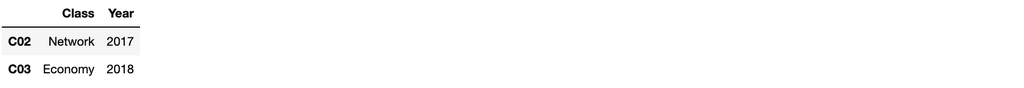

### 문제 [3-2] - 3점

### Year 열(column)에서 년도가 2018년도 혹은 2019년도에 개설된 Class 를 출력하세요.

<출력예시>

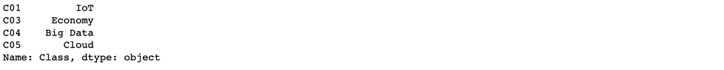

### 문제 [3-3] - 5점

### 강의 별 price 에 대한 세로형 막대 그래프를 출력하세요.

<출력예시>

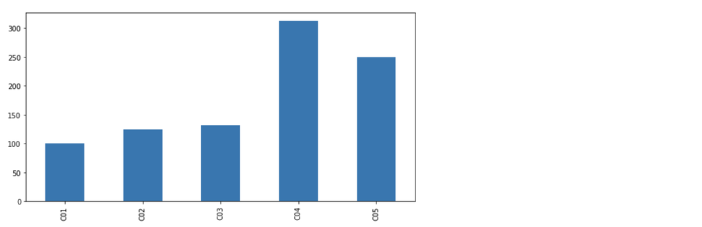

### 문제 [3-4] - 10점

### priceLevel 열(column)을 추가하고 Price 열(column)의 값이 200보다 크거나 같으면 'High', 200 보다 작으면 'Low'를 할당하여 출력하세요.

### 이 때, get_priceLevel() 함수를 생성하여 priceLevel열의 값들을 추가하세요.

<출력예시>

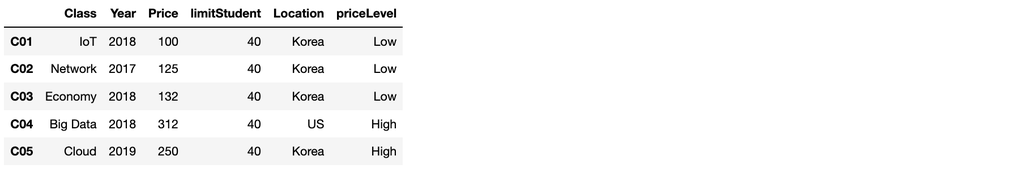

# 문제4 - 20점

### 문제 [4-1] - 2점

### titanic.csv 를 titanic 변수에 저장하여 불러와주세요.

### 변수설명

- Survived : (0 : No, 1 : Yes) - 범주형
- pclass : Passenger Class (1=1st, 2=2nd, 3= 3rd) - 범주형
- Name
- Sex : 성별 -범주형
- Age : 나이
- SibSp : 동반한 배우자 / 형제 자매 수 - 수치형
- Parch : 부모 / 자식 수 - 수치형
- Ticket : 티켓번호 - 수치형
- fare : 승선 요금 - 수치형
- Cabin : 객실번호
- Embarked : 승선 항구 이름 (C = Chenbourg , Q = Queenstown, S = Southampton)

### 문제 [4-2] - 2점

### 결측값을 확인하세요.

### 문제 [4-3] - 4점

### 변수 Ticket, Cabin을 제거하세요.

### 문제 [4-4] - 6점

### age 변수의 결측값을 중간값으로 채워넣으세요.

### 문제 [4-5] - 6점

### 'Embarked' 변수의 결측값을 'S'로 채워넣으세요.

# 문제 5 - 15점

### 문제 [5-1] - 3점

### 인구수예제.xlsx를 data_p로 불러온 후, 위에서부터 5행을 출력하세요.

<출력예시>

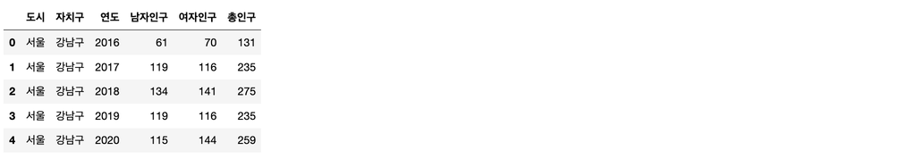

### 문제 [5-2] - 5점

### 연도별/도시별 총인구수를 구하세요.

<출력예시>

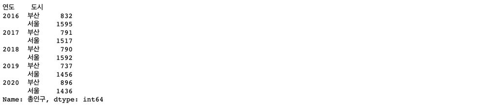

### 문제 [5-3] - 7점

### 도시/자치구별 평균 남자인구수와 여자인구수를 구하세요.

<출력예시>

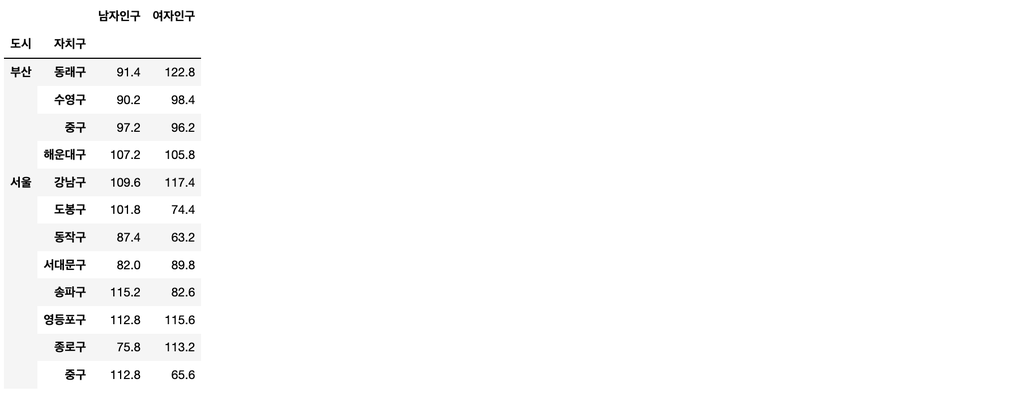